# Coursera_Data-Science_Programming-with-R_Notes

** Please note ** Note that there are other ways to call the plot command, i.e., using the “formula” interface. For example, we get a similar plot to the above with plot(dist ~ speed, cars). However, we will wait till later in the lesson before using the formula interface.

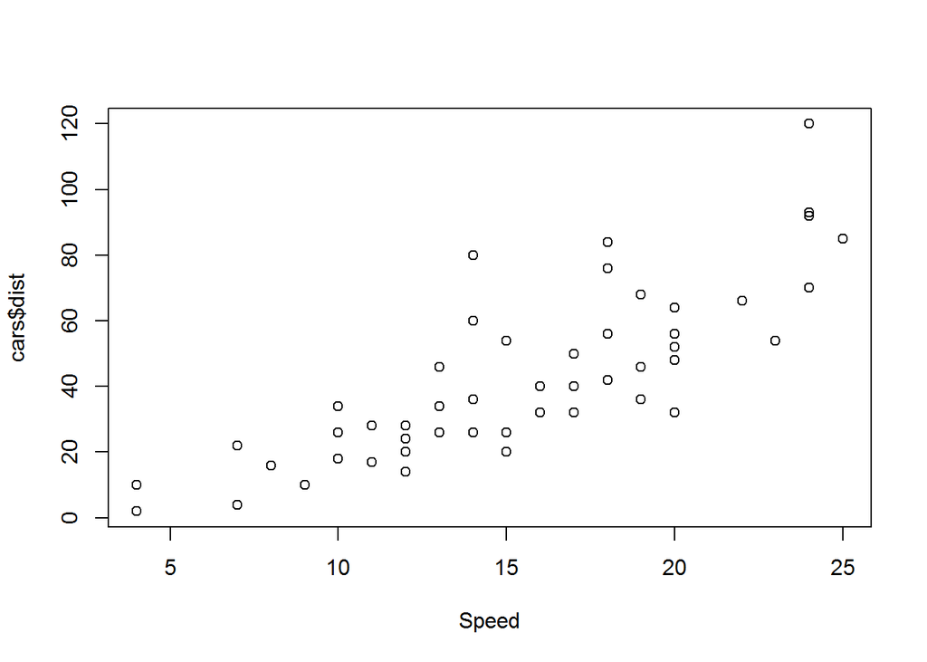

```r
plot(x = cars$speed, y = cars$dist, xlab = "Speed")  # x-axis label
```

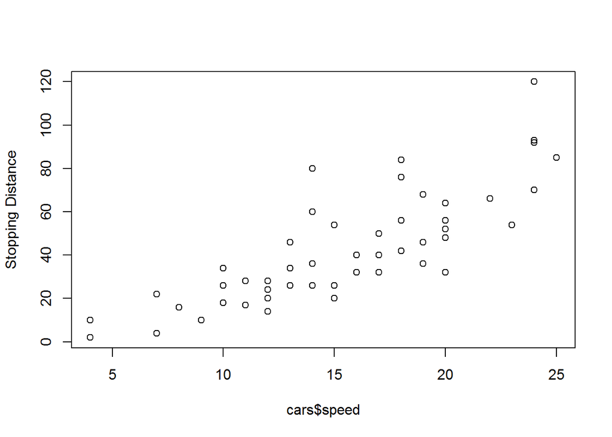

```r
plot(x = cars$speed, y = cars$dist, ylab = "Stopping Distance")  # y-axis label
```

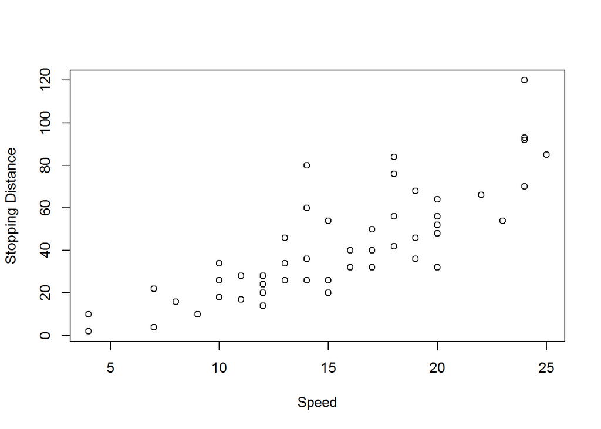

```r
plot(x = cars$speed, y = cars$dist, xlab = "Speed", ylab = "Stopping Distance")
```

The reason that plots(cars) worked at the beginning of the lesson was that R was smart enough to know that the first element (i.e., the first column) in cars should be assigned to the x argument and the second element to the y argument. To save on typing, the next set of answers will all be of the form, plot(cars, …) with various arguments added.

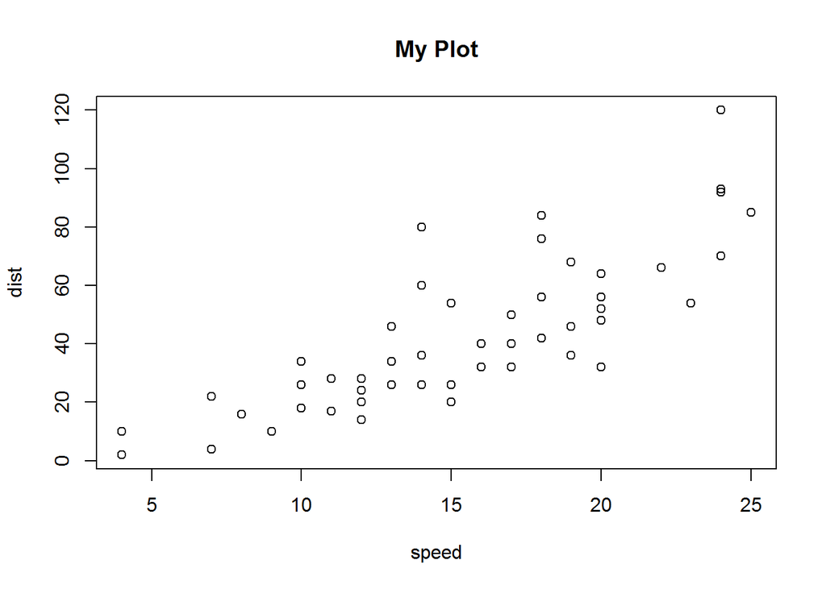

```r
plot(cars, main = "My Plot")
```

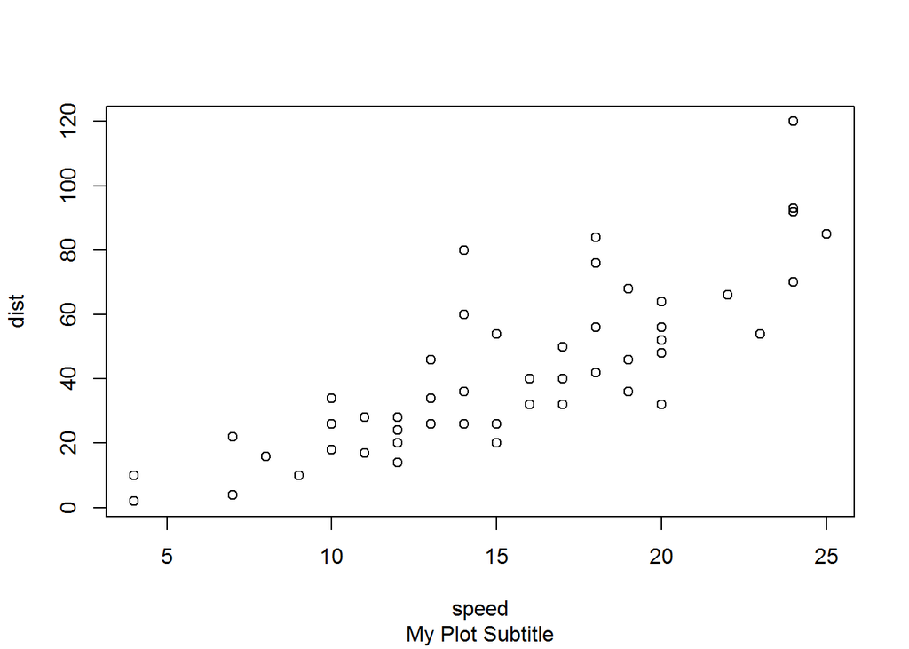

```r
plot(cars, sub = "My Plot Subtitle")
```

The plot help page (?plot) only covers a small number of the many arguments that can be passed in to plot() and to other graphical functions. To begin to explore the many other options, look at ?par. Let’s look at some of the more commonly used ones. Continue using plot(cars, …) as the base answer to these questions.

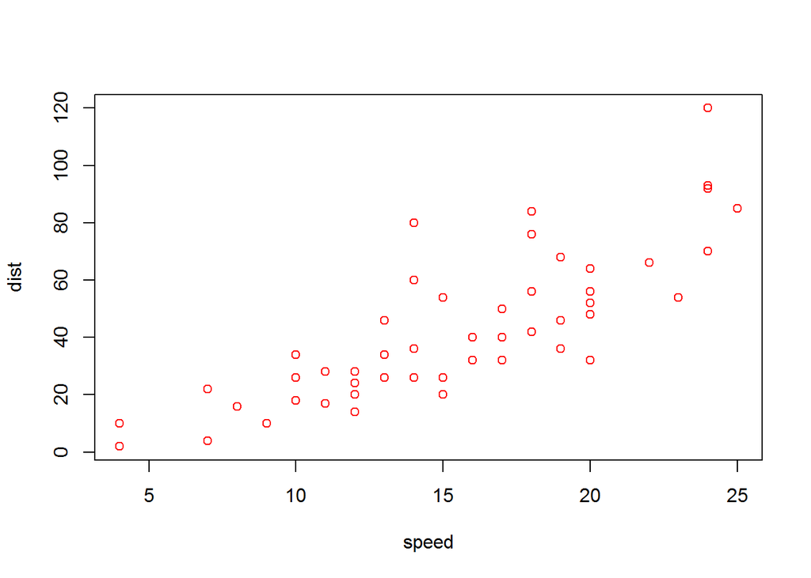

```r
 plot(cars, col = 2)  # points in red
```

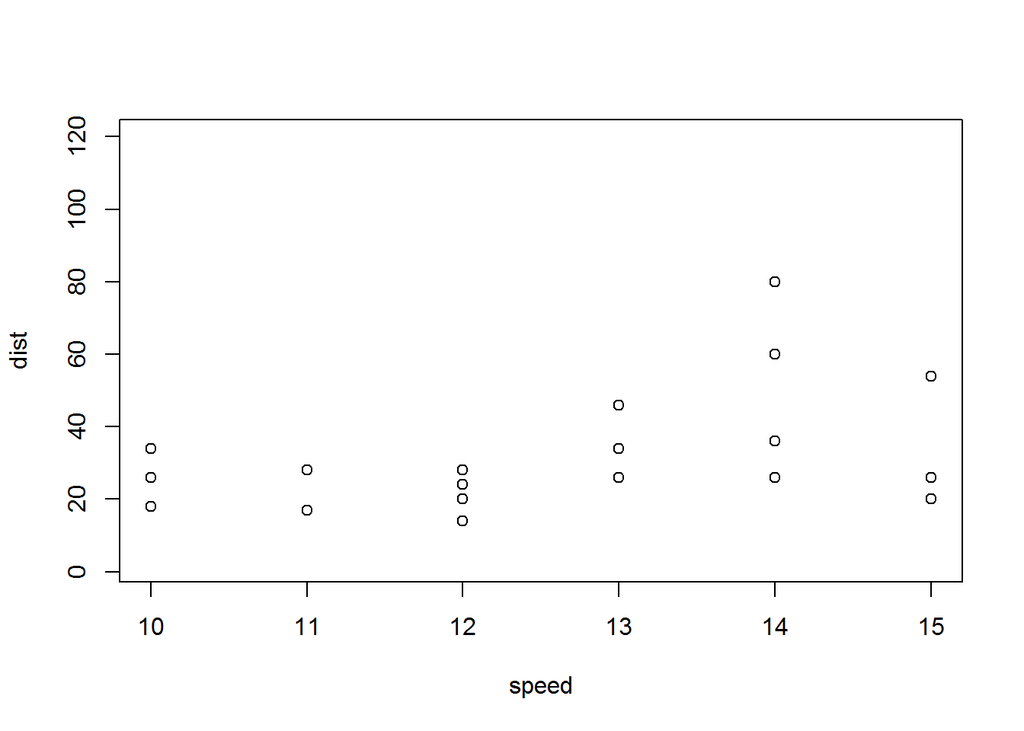

```r
plot(cars, xlim = c(10, 15))  # limiting x-axis
```

You can also change the shape of the symbols in the plot. The help page for points (?points) provides the details.

Plot cars using triangles. (Use pch = 2 to achieve this effect.)

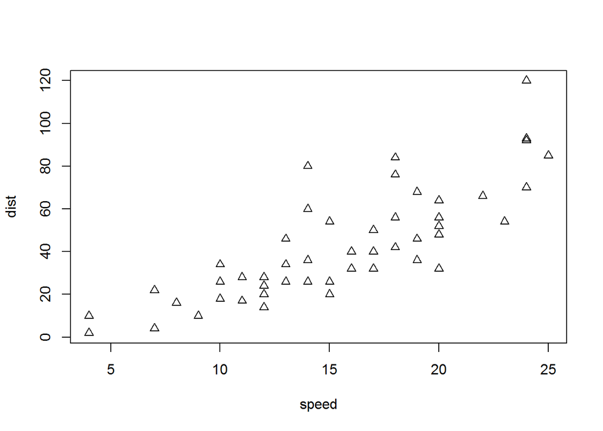

```r
plot(cars, pch = 2)
```

#### Boxplots

```r
data(mtcars)
dim(mtcars)
```

```
## [1] 32 11
```

```r
head(mtcars)
```

```
##                    mpg cyl disp  hp drat    wt  qsec vs am gear carb
## Mazda RX4         21.0   6  160 110 3.90 2.620 16.46  0  1    4    4
## Mazda RX4 Wag     21.0   6  160 110 3.90 2.875 17.02  0  1    4    4
## Datsun 710        22.8   4  108  93 3.85 2.320 18.61  1  1    4    1
## Hornet 4 Drive    21.4   6  258 110 3.08 3.215 19.44  1  0    3    1
## Hornet Sportabout 18.7   8  360 175 3.15 3.440 17.02  0  0    3    2
## Valiant           18.1   6  225 105 2.76 3.460 20.22  1  0    3    1
```

Anytime that you load up a new data frame, you should explore it before using it. In the middle of a swirl lesson, just type play(). This temporarily suspends the lesson (without losing the work you have already done) and allows you to issue commands like dim(mtcars) and head(mtcars). Once you are done examining the data, just type nxt() and the lesson will pick up where it left off.

```r
?boxplot
```

Instead of adding data columns directly as input arguments, as we did with plot(), it is often handy to pass in the entire data frame. This is what the “data” argument in boxplot() allows.

boxplot(), like many R functions, also takes a “formula” argument, generally an expression with a tilde (“~”) which indicates the relationship between the input variables. This allows you to enter something like mpg ~ cyl to plot the relationship between cyl (number of cylinders) on the x-axis and mpg (miles per gallon) on the y-axis.

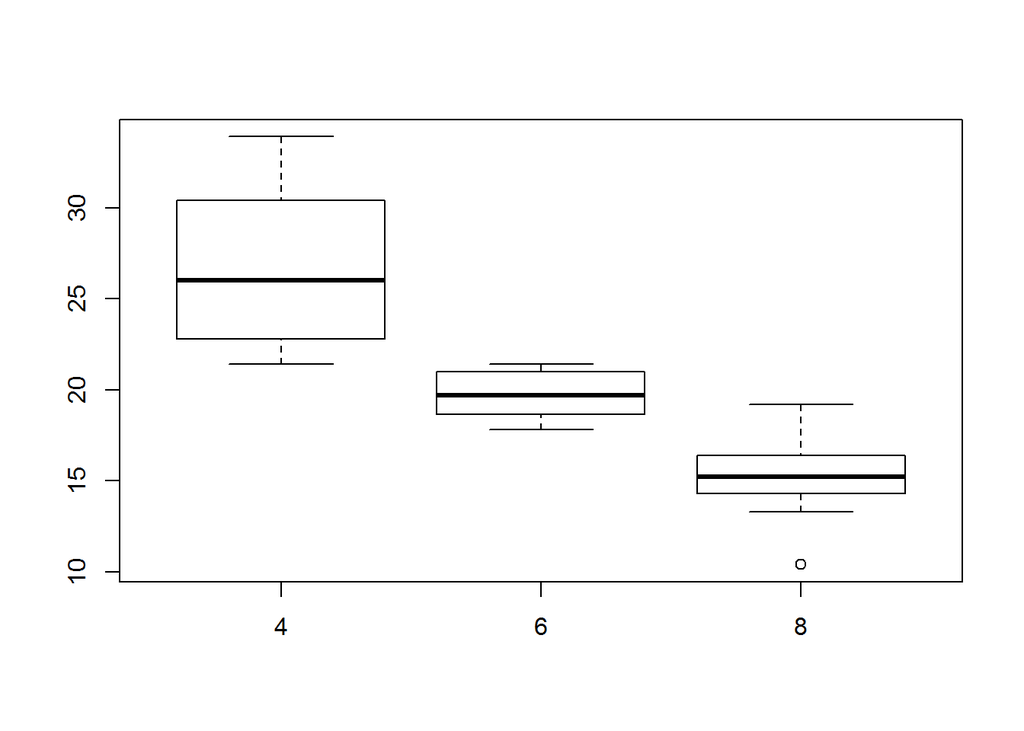

```r
boxplot(formula = mpg ~ cyl, data = mtcars)
```

The plot shows that mpg is much lower for cars with more cylinders. Note that we can use the same set of arguments that we explored with plot() above to add axis labels, titles and so on.

When looking at a single variable, histograms are a useful tool. hist() is the associated R function. Like plot(), hist() is best used by just passing in a single vector.

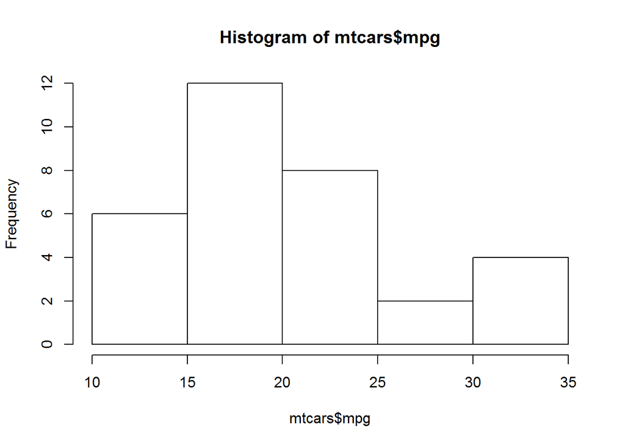

```r
hist(mtcars$mpg)
```

If you want to explore other elements of base graphics, then this web page (http://www.ling.upenn.edu/~joseff/rstudy/week4.html) provides a useful overview.